# Practical Machine Learning Course Project

Sally Cochrane

10/29/2021

### Introduction

The goal of this project is to predict the manner in which participants did an exercise. The data come from accelerometers worn on the belt, forearm, arm, and dumbell of 6 participants who were asked to perform lifts correctly and incorrectly in 5 different ways. As the original paper describes it:

“Six young health participants were asked to perform one set of 10 repetitions of the Unilateral Dumbbell Biceps Curl in five different fashions: exactly according to the specification (Class A), throwing the elbows to the front (Class B), lifting the dumbbell only halfway (Class C), lowering the dumbbell only halfway (Class D) and throwing the hips to the front (Class E).”

The data for this exercise come from:

Velloso, E.; Bulling, A.; Gellersen, H.; Ugulino, W.; Fuks, H. Qualitative Activity Recognition of Weight Lifting Exercises. Proceedings of 4th International Conference in Cooperation with SIGCHI (Augmented Human ’13) . Stuttgart, Germany: ACM SIGCHI, 2013.

```r
library(dplyr)
library(readr)
library(caret)
library(ggplot2)
library(AppliedPredictiveModeling)
set.seed(11)
```

#### Pre-processing the Data:

First I loaded the data and split the training set into a training set (with 13737 rows), which I used to build my model, and a testing set with (5885 rows) to evaluate the model.

```r
training_full <- read_csv("https://d396qusza40orc.cloudfront.net/predmachlearn/pml-training.csv")
final_testing <- read_csv("https://d396qusza40orc.cloudfront.net/predmachlearn/pml-testing.csv")
```

```r
# split training data for validation:

inTrain <- createDataPartition(y = training_full$classe, p = 0.7, list = FALSE)
training0 <- training_full[inTrain, ]
testing0 <- training_full[-inTrain, ]

dim(training0)
```

```
## [1] 13737   160
```

```r
dim(testing0)
```

```
## [1] 5885  160
```

Since there were a *lot* of variables (columns), the first step in preparing the data was to see if any of the variables have **near-zero variance**. Many did, and I removed them from the dataset. Variables with many NA’s were also identified and removed, as well as the variables that only served to identify the participant, as they are unnecessary to building the model.

```r
# Clean the data:

  # 1. find near zero variables and remove those columns from the data set:
nzv <- nearZeroVar(training0)
train <- training0[, -nzv]
test <- testing0[, -nzv]

# remove columns used to identify user/time (X1, user_name, timestamps 1 and 2, converted timestamp).

training <- train[, -(1:5)]
testing <- test[, -(1:5)]

# Lots of variables have many NA's. Look at number of na's in each variable: [not run to save space]

# sapply(training, function(x)sum(is.na(x)))

    # Remove variables with lots of NA's:

removeNA <- sapply(training, function(x)sum(is.na(x))) > 1
training <- training[, removeNA == FALSE]
testing <- testing[, removeNA == FALSE]
```

Next, I checked whether any of the variables were highly correlated (over 0.8). Many were, which suggests that **principal component analysis** might be useful.

```r
# Correlation? Should we do PCA?

M <- abs(cor(training[,-54]))
diag(M) <- 0 # all variables correlate with themselves 1
highly_correlated <- which(M > 0.8, arr.ind=TRUE) # find variables over .8 correlated

highly_correlated
```

```
##                  row col
## yaw_belt           4   2
## total_accel_belt   5   2
## accel_belt_y      10   2
## accel_belt_z      11   2
## accel_belt_x       9   3
## magnet_belt_x     12   3
## roll_belt          2   4
## roll_belt          2   5
## accel_belt_y      10   5
## accel_belt_z      11   5
## pitch_belt         3   9
## magnet_belt_x     12   9
## roll_belt          2  10
## total_accel_belt   5  10
## accel_belt_z      11  10
## roll_belt          2  11
## total_accel_belt   5  11
## accel_belt_y      10  11
## pitch_belt         3  12
## accel_belt_x       9  12
## gyros_arm_y       20  19
## gyros_arm_x       19  20
## magnet_arm_x      25  22
## accel_arm_x       22  25
## magnet_arm_z      27  26
## magnet_arm_y      26  27
## accel_dumbbell_x  35  29
## accel_dumbbell_z  37  30
## gyros_dumbbell_z  34  32
## gyros_forearm_z   47  32
## gyros_dumbbell_x  32  34
## gyros_forearm_z   47  34
## pitch_dumbbell    29  35
## yaw_dumbbell      30  37
## gyros_forearm_z   47  46
## gyros_dumbbell_x  32  47
## gyros_dumbbell_z  34  47
## gyros_forearm_y   46  47
```

These plots show two examples of two highly correlated variables:

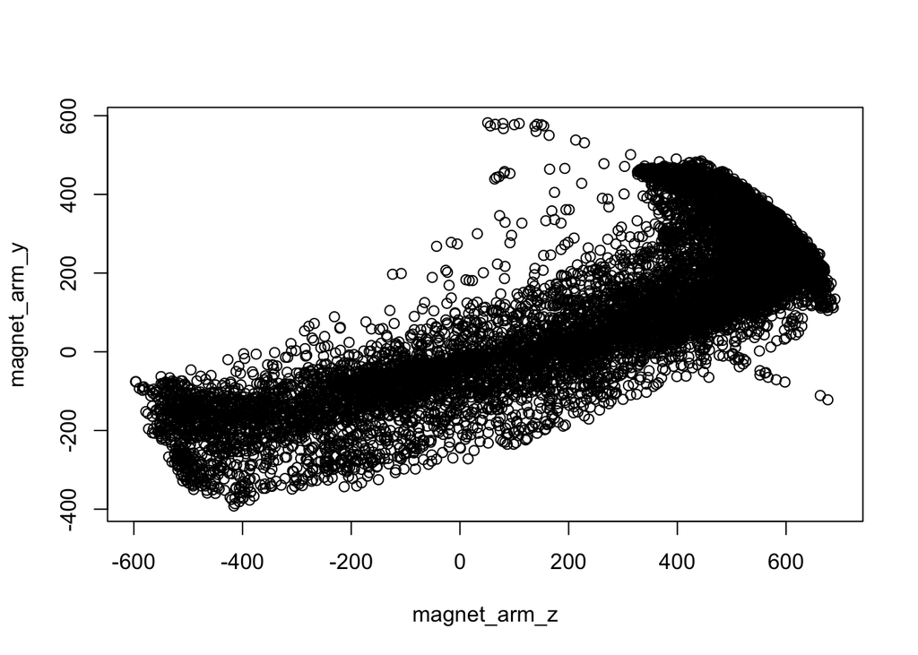

```r
plot(training$magnet_arm_z, training$magnet_arm_y, xlab = "magnet_arm_z", ylab = "magnet_arm_y")
```

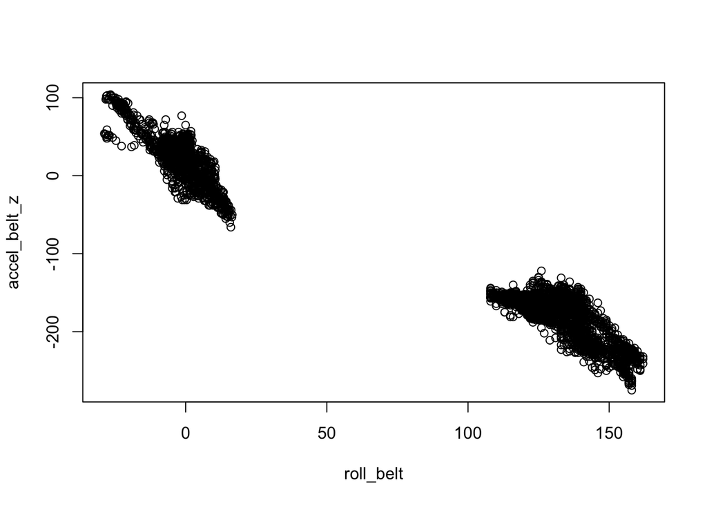

```r
plot(training$roll_belt, training$accel_belt_z, xlab = "roll_belt", ylab = "accel_belt_z")
```

I preprocessed the data with principal component analysis, and applied the PCA from the training data to the test data.

```r
## Principal component analysis preprocessing:

preProc <- preProcess(training, method = 'pca', thresh = 0.8)
trainPC <- predict(preProc, training[, -54])
testPC <- predict(preProc, testing[, -54])
```

#### Fit the Models on the Training Data

```r
## Model 1: Random Forest w/ cv:
modelFit1_pca <- train(x = trainPC, y = training$classe, method = 'rf',
                  trControl = trainControl(method = "cv"), number = 3)

## Model 2: Gradient Boosted Tree:
modelFit2_pca <- train(x = trainPC, y = training$classe, method = "gbm", verbose = FALSE)

## Model 3: Support Vector Machine:
modelFit3_pca <- e1071::svm(x = trainPC, y = as.factor(training$classe))
```

#### Predict the classes on the test set

Using these models, I predicted outcomes for the test set and evaluated the accuracy of each model using a confusion matrix of predicted outcomes vs. actual outcomes. This step estimates the out-of-sample accuracy of the models.

```r
## Predict on the testing set:

pred1 <- predict(modelFit1_pca, testPC)
pred2 <- predict(modelFit2_pca, testPC)
pred3 <- predict(modelFit3_pca, testPC)
```

#### Choose a Final Model

```r
# Evaluate errors on test set:
confusionMatrix(as.factor(testing$classe), pred1) # 0.9675
```

```
## Confusion Matrix and Statistics
##
##           Reference
## Prediction    A    B    C    D    E
##          A 1644    5   12   12    1
##          B   25 1092   17    3    2
##          C    4   13  989   14    6
##          D    3    5   43  909    4
##          E    0    4    5   10 1063
##
## Overall Statistics
##
##                Accuracy : 0.9681
##                  95% CI : (0.9632, 0.9724)
##     No Information Rate : 0.2848
##     P-Value [Acc > NIR] : < 2.2e-16
##
##                   Kappa : 0.9596
##
##  Mcnemar's Test P-Value : 5.29e-06
##
## Statistics by Class:
##
##                      Class: A Class: B Class: C Class: D Class: E
## Sensitivity            0.9809   0.9759   0.9278   0.9589   0.9879
## Specificity            0.9929   0.9901   0.9923   0.9889   0.9960
## Pos Pred Value         0.9821   0.9587   0.9639   0.9429   0.9824
## Neg Pred Value         0.9924   0.9943   0.9842   0.9921   0.9973
## Prevalence             0.2848   0.1901   0.1811   0.1611   0.1828
## Detection Rate         0.2794   0.1856   0.1681   0.1545   0.1806
## Detection Prevalence   0.2845   0.1935   0.1743   0.1638   0.1839
## Balanced Accuracy      0.9869   0.9830   0.9600   0.9739   0.9920
```

```r
confusionMatrix(as.factor(testing$classe), pred2) # 0.764
```

```
## Confusion Matrix and Statistics
##
##           Reference
## Prediction    A    B    C    D    E
##          A 1374   58   82  131   29
##          B   92  824  128   62   33
##          C   93   76  803   38   16
##          D   52   54  105  728   25
##          E   47  101   84   59  791
##
## Overall Statistics
##
##                Accuracy : 0.7681
##                  95% CI : (0.7571, 0.7788)
##     No Information Rate : 0.2817
##     P-Value [Acc > NIR] : < 2.2e-16
##
##                   Kappa : 0.7069
##
##  Mcnemar's Test P-Value : < 2.2e-16
##
## Statistics by Class:
##
##                      Class: A Class: B Class: C Class: D Class: E
## Sensitivity            0.8287   0.7403   0.6681   0.7151   0.8848
## Specificity            0.9290   0.9340   0.9524   0.9515   0.9417
## Pos Pred Value         0.8208   0.7234   0.7827   0.7552   0.7311
## Neg Pred Value         0.9326   0.9391   0.9179   0.9411   0.9786
## Prevalence             0.2817   0.1891   0.2042   0.1730   0.1519
## Detection Rate         0.2335   0.1400   0.1364   0.1237   0.1344
## Detection Prevalence   0.2845   0.1935   0.1743   0.1638   0.1839
## Balanced Accuracy      0.8789   0.8372   0.8102   0.8333   0.9132
```

```r
confusionMatrix(as.factor(testing$classe), pred3) # 0.8714
```

```
## Confusion Matrix and Statistics
##
##           Reference
## Prediction    A    B    C    D    E
##          A 1514   35   64   53    8
##          B   98  918   95   17   11
##          C   20   43  922   28   13
##          D   10   17   99  835    3
##          E    7   29   32   47  967
##
## Overall Statistics
##
##                Accuracy : 0.8761
##                  95% CI : (0.8674, 0.8844)
##     No Information Rate : 0.2802
##     P-Value [Acc > NIR] : < 2.2e-16
##
##                   Kappa : 0.8435
##
##  Mcnemar's Test P-Value : < 2.2e-16
##
## Statistics by Class:
##
##                      Class: A Class: B Class: C Class: D Class: E
## Sensitivity            0.9181   0.8810   0.7607   0.8520   0.9651
## Specificity            0.9622   0.9544   0.9777   0.9737   0.9764
## Pos Pred Value         0.9044   0.8060   0.8986   0.8662   0.8937
## Neg Pred Value         0.9679   0.9739   0.9403   0.9705   0.9927
## Prevalence             0.2802   0.1771   0.2059   0.1665   0.1703
## Detection Rate         0.2573   0.1560   0.1567   0.1419   0.1643
## Detection Prevalence   0.2845   0.1935   0.1743   0.1638   0.1839
## Balanced Accuracy      0.9402   0.9177   0.8692   0.9129   0.9708
```

```r
final_testing_pca <- predict(preProc, final_testing[, -160])
pred_final <- predict(modelFit1_pca, final_testing_pca)

as.data.frame(pred_final)
```

```
##    pred_final
## 1           B
## 2           A
## 3           A
## 4           A
## 5           A
## 6           E
## 7           D
## 8           B
## 9           A
## 10          A
## 11          B
## 12          C
## 13          B
## 14          A
## 15          E
## 16          E
## 17          A
## 18          B
## 19          B
## 20          B
```